# Introduced Species in Ontario

This is an abridged version of the blog post found here.

```r
library(ggplot2)
library(reshape2)
library(packcircles) # For bubble chart
```

# Run the query

```r
source("../src/query.R")
# ont_spp <- ask_query_titles_properties("[[Distribution::Ont.]]|?Special status|?Introduced|?Taxon family|?Taxon parent|?Volume", "ontario_species.csv")
ont_spp <- read_csv("ontario_species.csv")
```

# Clean the data

The introduction status of a taxon provided by the Flora of North America is NA if no information has been provided by the treatment author. I am going to make the assumption that if no information has been provided, the plant is **not introduced**.

Let’s rename this value to something more readable.

```r
ont_spp <- select(ont_spp, -X1) # Remove imported row indices
names(ont_spp) <- names(ont_spp) %>% tolower %>% sub(" ", "_", .) # clean up colnames

ont_spp$introduced <- ont_spp$introduced %>% replace_na(., "Native") %>% recode("TRUE" = "Introduced")

# Transform the data into long-format for ease of visualization
melted_ont_spp <- melt(ont_spp, id.vars = "taxon_name")
```

# Visualize the data

## How many plants in Ontario are introduced?

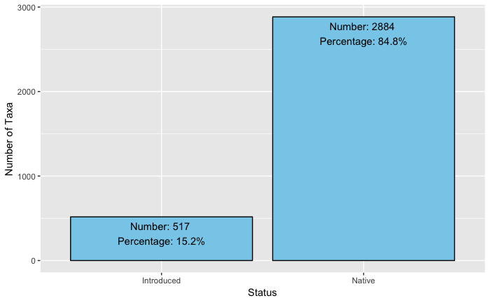

```r
introduced_subset <- subset(melted_ont_spp, variable == "introduced") %>% distinct # One record per species
ggplot(data = introduced_subset, aes(x = value)) +
  geom_bar(fill = "sky blue", colour = "black") +
  # coord_flip() +
  labs(x = "Status", y = "Number of Taxa") +
  geom_text(stat="count",
            aes(label=round(..count../sum(..count..)*100, 2) %>% paste("Number: ", ..count.., " \nPercentage: ", ., "%", sep="")),
            position=position_dodge(width=0.9), vjust=1.25) # position_dodge and vjust not working
```

```r
# TODO: Colour by taxon rank
```

From the above plot, I see that 15% of taxa found in Ontario described in the Flora of North America are introduced species.

## How many plants in Ontario are weedy?

Due to limitations in data capture, [special status data are only available in in the following volumes: V3, V6, V9, V12, V17, V28](http://dev.floranorthamerica.org/Sample_Queries#Special_Status).

I’d like to visualize what this means for my dataset in terms of data coverage.

```r
volume_subset <- subset(melted_ont_spp, variable == "volume") %>% distinct
var_counts <- count(volume_subset$value)
names(var_counts) <- c("volume", "freq")
packing <- circleProgressiveLayout(var_counts$freq, sizetype='area')
packing <- cbind(packing, rownames(packing))
names(packing) <- c("x", "y", "radius", "id")

colour <- data.frame("data_present" = rep("Yes", 6), "volume" = c("Volume 3", "Volume 6", "Volume 9", "Volume 12", "Volume 17", "Volume 28"))

counts_data <- cbind(var_counts, packing)

var_counts <- full_join(var_counts, colour, by = "volume")
```

```
Column `volume` joining factors with different levels, coercing to character vector
```

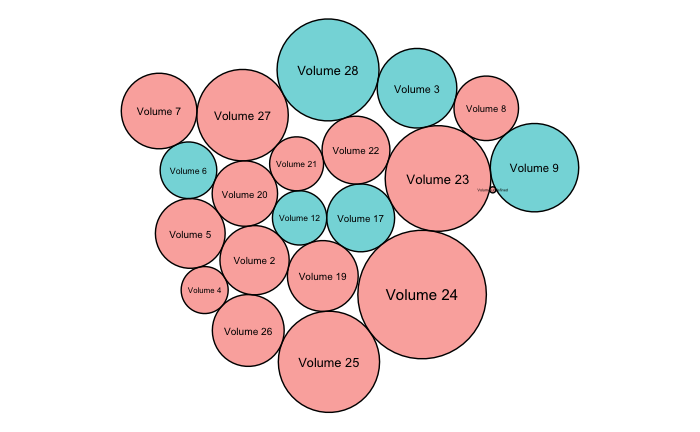

```r
var_counts$data_present <- var_counts$data_present %>% as.character %>% replace_na("No")
circle_colours <- var_counts %>% select(data_present) %>% cbind(., rownames(.))
names(circle_colours) <- c("data_present", "id")

dat_gg <- circleLayoutVertices(packing, npoints=50, idcol=4)
dat_gg <- join(dat_gg, circle_colours, by = "id")

ggplot() +
  geom_polygon(data = dat_gg, aes(x, y, group = id, fill=as.factor(data_present)), colour = "black", alpha = 0.6) +
  # Add text in the center of each bubble + control its size
  geom_text(data = counts_data, aes(x, y, size=freq, label = volume)) +
  scale_size_continuous(range = c(1,4)) +
  theme_void() +
  theme(legend.position="none") +
  coord_equal()
```

Most of my data comes from volumes 23 and 24, however special status data is not available for these volumes. You can see the volumes in blue above that have special status data.

In total, special status data is only available for 30.8717675% of the dataset.

Unfortunately, the conclusions of my work will be biased.

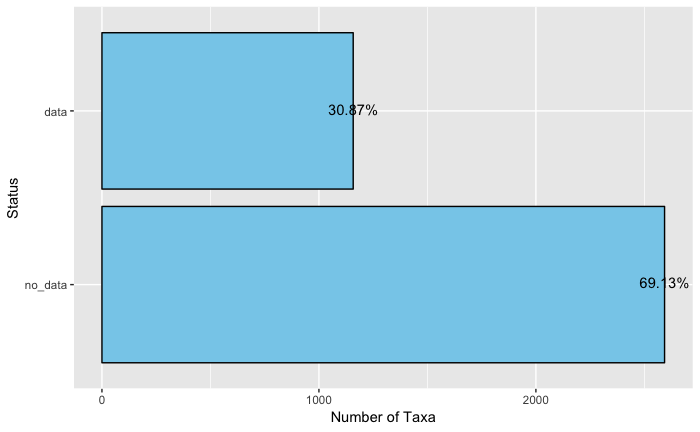

```r
special_status_subset <- subset(melted_ont_spp, variable == "special_status")

no_data <- special_status_subset[is.na(special_status_subset$value) == TRUE,] %>% cbind(., "no_data")
names(no_data)[4] <- "data_present"
data_present <- special_status_subset[!is.na(special_status_subset$value),] %>% cbind(., "data")
names(data_present)[4] <- "data_present"
special_status_data_presence <- rbind(no_data, data_present)

ggplot(data = special_status_data_presence, aes(x = data_present)) +
  geom_bar(fill = "sky blue", colour = "black") +
  coord_flip() +
  labs(x = "Status", y = "Number of Taxa") +
  geom_text(stat="count",
            aes(label=round(..count../sum(..count..)*100, 2) %>% paste(., "%", sep="")),
            vjust=0.3) # position_dodge and vjust not working
```

Within the ~31% of taxa with special status data, we see the breakdown of status below.

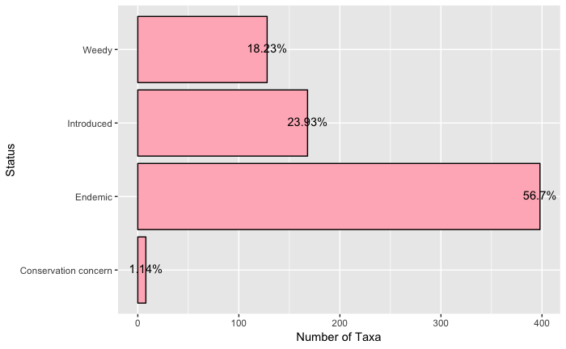

```r
special_status_subset <- special_status_subset %>% drop_na() %>% filter(., value != "Illustrated")

ggplot(data = special_status_subset, aes(x = value)) +
  geom_bar(fill = "lightpink", colour = "black") +
  coord_flip() +
  labs(x = "Status", y = "Number of Taxa") +
  geom_text(stat="count",
            aes(label=round(..count../sum(..count..)*100, 2) %>% paste(., "%", sep="")),
            vjust=0.3) # position_dodge and vjust not working
```

It is more common to be introduced than to be weedy. Only a small fraction of taxa are considered to be of conservation concern.

## What is the likelihood is that the plant is introduced, given it is weedy?

I’d like to further investigate the relationship between weediness and introduction status.

```r
ont_spp %>%
  summarize(weedy_prob = sum(special_status == "Weedy" & introduced == "Introduced", na.rm = TRUE)/sum(special_status == "Weedy", na.rm = TRUE))
```

| weedy_prob |
| --- |
| 0.453125 |

```r
ont_spp %>%
  summarize(prob = sum(introduced == "Introduced", na.rm = TRUE)/sum(introduced == "Introduced" | introduced == "Native", na.rm = TRUE))
```

| prob |
| --- |
| 0.1684884 |

```r
NA
```

From the above, I see that **being weedy greatly increases the probability that a plant is an introduced species**. This makes sense given my understanding of what makes introduced species successful.

## What is the taxonomic make-up of these two groups (introduced and weedy)?

Which families are the largest offenders?

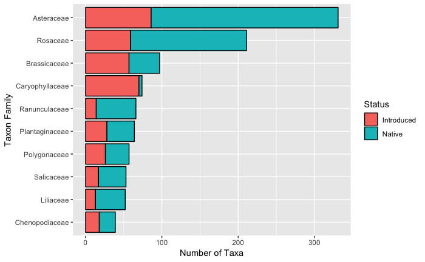

```r
taxonomy_subset <- select(ont_spp, -special_status) %>% distinct
family_introduced_counts <- taxonomy_subset %>% filter(introduced == "Introduced") %>% dplyr::count(taxon_family, sort = TRUE) %>% top_n(., 10)
family_native_counts <- taxonomy_subset %>% filter(introduced == "Native") %>% dplyr::count(taxon_family)
counts_to_plot <- inner_join(family_introduced_counts, family_native_counts, by = "taxon_family")
names(counts_to_plot) <- c("taxon_family", "num_introduced", "num_native")
counts_to_plot <- melt(counts_to_plot) %>% group_by(variable) %>% dplyr::arrange(desc(value), .by_group = TRUE)
ggplot(data = counts_to_plot, aes(x = reorder(taxon_family, value), y = value, fill = variable)) +
  geom_bar(stat = "identity", position = position_stack(reverse = TRUE), colour="black") +
  coord_flip() + labs(x = "Taxon Family", y = "Number of Taxa") +
  scale_fill_discrete(name = "Status", labels = c("Introduced", "Native"))
```

```r
NA
NA
```

Although by numbers, **Asteraceae** contributes the most number of introduced species to the Flora of Ontario, **Caryophyllaceae** is almost entirely comprised of introduced species. Rosaceae and Brassicaceae also contribute greatly in terms of numbers to the introduced flora, with Brassiceae being a family most dominated by introduced taxa.

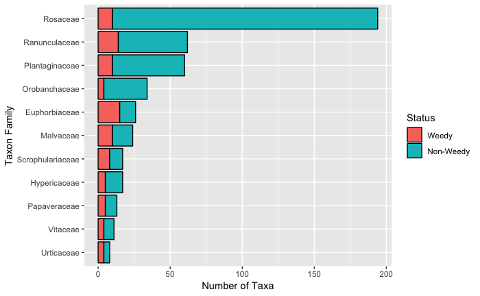

```r
taxonomy_subset_special_status <- ont_spp %>% filter(special_status != "Illustrated") %>% drop_na

family_weedy_counts <- taxonomy_subset_special_status %>% filter(special_status == "Weedy") %>% dplyr::count(taxon_family, sort = TRUE) %>% top_n(., 10)
family_non_weedy_counts <- taxonomy_subset_special_status %>% filter(special_status != "Weedy") %>% drop_na %>% dplyr::count(taxon_family)
counts_to_plot <- inner_join(family_weedy_counts, family_non_weedy_counts, by = "taxon_family")
names(counts_to_plot) <- c("taxon_family", "num_weedy", "num_non_weedy")
counts_to_plot <- melt(counts_to_plot) %>% group_by(variable) %>% dplyr::arrange(desc(value), .by_group = TRUE)
ggplot(data = counts_to_plot, aes(x = reorder(taxon_family, value), y = value, fill = variable)) +
  geom_bar(stat = "identity", position = position_stack(reverse = TRUE), colour="black") +
  coord_flip() + labs(x = "Taxon Family", y = "Number of Taxa") +
  scale_fill_discrete(name = "Status", labels = c("Weedy", "Non-Weedy"))
```

```r
NA
NA
```

The **Euphorbiaceae** family contains the most number of weedy species, in absolute terms and as a percentage of the totaly number of taxa in the group (total number: 15, percentage of group: 57.69).